# Math 151AH: HW1

# Problem 1

### a)

```python
import math
import matplotlib.pyplot as plt
print("Calculated:\n",1 - math.cos(10**-3))
print("True:\n","4.9999995833333472222219742063519620811078710385413014376488... ×10^-7")
```

```
Calculated:
 4.999999583255033e-07
True:
 4.9999995833333472222219742063519620811078710385413014376488... ×10^-7
```

Accurate to 10 digits.

### b)

Identity: $1-\cos(\theta)=2\sin^2(\frac{\theta}2)$

### c)

```python
print(2*math.sin(10**-3 / 2)**2)
```

```
4.999999583333347e-07
```

Accurate to all 16 digits; this is much better than before.

# Problem 2

### a)

By Taylor's Theorem, $$\sin(\frac{\pi}2+\delta) = \sin(\frac{\pi}2)-\frac12\sin(\zeta)\delta^2$$ for $\zeta\in(\frac\pi2,\frac\pi2+\delta)$. Therefore $$ \begin{aligned} |\sin(\frac\pi2)-\sin(\frac\pi2+\delta)|&<10^{-\beta} \\ \Rightarrow\frac12\sin(\zeta)\delta^2&<10^{-\beta} \\ \Rightarrow\delta^2&<\frac{2*10^{-\beta}}{\sin(\zeta)} \\ \Rightarrow\delta^2&<\frac{2*10^{-\beta}}{\sin(\frac\pi2+1)} \\ \Rightarrow\delta&<\sqrt{\frac{2*10^{-\beta}}{\sin(\frac\pi2+1)}} \end{aligned} $$

### b)

```python
fun = lambda x: math.sin(math.pi / 2 + x)

d = 0.1
lowest_not = 1
highest_is = 0
for i in range(1000):
  if fun(d) == 1:
    highest_is = d
  else:
    lowest_not = d
  d = (highest_is + lowest_not)/2

print(f"delta = {d}")
```

```
delta = 1.0536712280462268e-08
```

# Problem 3

### a)

$$ \begin{aligned} f(x)&=1.01e^{4x}-4.62e^{3x}-3.11e^{2x}+12.2e^x-1.99 \\ f(1.53)&=1.01(4.62^4)-4.62(4.62^3)-3.11(4.62^2)+12.2(4.62)-1.99 \\ &= 1.01(21.3^2)-(21.3^2)-3.11(21.3)+56.4-1.99\\ &= 1.01(454)-454-66.2+56.4-1.99\\ &= 459 - 454-66.2+56.4-1.99\\ &= 5-66.2+56.4-1.99\\ &= -61.2+56.4-1.99\\ &= -4.8-1.99\\ &= -6.79 \end{aligned} $$

### b)

$$f(x)=e^x(e^x(e^x(1.01e^x-4.62)-3.11)+12.2)-1.99$$

### c)

$$ \begin{aligned} f(1.53)&= 4.62(4.62(4.62(1.01(4.62)-4.62)-3.11)+12.2)-1.99 \\ &= 4.62(4.62(4.62(0.05)-3.11)+12.2)-1.99 \\ &= 4.62(4.62(-2.88)+12.2)-1.99 \\ &= 4.62(-1.1)-1.99 \\ &= -7.07 \end{aligned} $$

### d)

The nested form has greater accuracy. Its error is almost half that of the original form.

# Problem 4

### a)

$\renewcommand\fl{\text{fl}}$ $$ \begin{aligned} e_k&=\fl(A_k)-A_k \\ &= (\fl(A_{k-1})+a_k)(1+\delta_k)-A_k \\ &= (1+\delta_k)\fl(A_{k-1})+(1+\delta_k)a_k-A_k \\ &= (1+\delta_k)(e_{k-1}+A_{k-1})+(1+\delta_k)a_k-A_k \\ &= (1+\delta_k)e_{k-1}+(1+\delta_k)(A_{k-1}+a_k)-A_k \\ &= (1+\delta_k)e_{k-1} + (1+\delta_k)A_k - A_k \\ &= (1+\delta_k)e_{k-1}+\delta_k A_k \end{aligned} $$

### b)

$$ \begin{aligned} e_k - e_{k-1} &= \delta_ke_{k-1}+\delta_k A_k \\ \Rightarrow \sum_{k=2}^n(e_k-e_{k-1}) &= \sum_{k=2}^n(\delta_ke_{k-1}+\delta_k A_k) \\ \Rightarrow e_n-e_1 &= \sum_{k=2}^n\delta_k A_k + \sum_{k=2}^n\delta_k e_{k-1} \\ \Rightarrow e_n &= \sum_{k=2}^n\delta_k A_k + \sum_{k=2}^n\delta_k e_{k-1} + e_1 \\ &= \sum_{k=2}^n\delta_k A_k + \sum_{k=2}^n\delta_k e_{k-1} \\ \end{aligned} $$

All that is left to show is $\sum_{k=2}^n\delta_k e_{k-1}=O(\epsilon_M^2)$: $$ \begin{aligned} |\sum_{k=2}^n\delta_k e_{k-1}|&\leq\sum_{k=2}^n|\delta_k e_{k-1}| \\ &\leq\sum_{k=2}^n\epsilon_M|e_{k-1}| \\ &\leq \sum_{k=2}^n\epsilon_M^2|A_{k-1}| &&(\text{Since }\frac{|e_{k-1}|}{|A_{k-1}|}\leq\epsilon_M^2) \\ &\leq \sum_{k=2}^n\epsilon_M^2A &&\text{for }A=\max_k\{|A_k|\} \\ &= A(n-1)\epsilon_M^2 \\ &= O(\epsilon_M^2) \end{aligned} $$ It is preferable to start with the smallest numbers so $A_k$ stays smaller longer. This reduces the effect of each $\delta_k$ on $e_n$. Starting with the larger numbers would keep $A_k$ large and increase the effect of each $\delta_k$.

# Problem 5

By Taylor's Theorem we have that $$ \begin{aligned} f(x)&=\frac1{t!}f^{(t)}(\zeta_0)(x-x^*)^t &&\text{for }\zeta_0\in(x^*,x)\\ \text{and } f'(x)&= \frac1{(t-1)!}f^{(t)}(\zeta_1)(x-x^*)^{t-1} &&\text{for }\zeta_1\in(x^*,x)\\ \end{aligned} $$ Then for Newton's method with $x_n=x_{n-1}-\frac{f(x_{n-1})}{f'(x_{n-1})}$, $$ \begin{aligned} |x_n-x^*|&=|f(x_{n-1})-x^*| \\ &= |x_{n-1}-\frac1t\frac{f^{(t)}(\zeta_{0n})}{f^{(t)}(\zeta_{1n})}(x_{n-1}-x^*)-x^*| &&\text{for }\zeta_{0n},\zeta_{1n}\in(x^*,x_{n-1})\\ &= |x_{n-1}-x^*||1-\frac1t\frac{f^{(t)}(\zeta_{0n})}{f^{(t)}(\zeta_{1n})}| \\ \Rightarrow \lim_{n\rightarrow\infty}\frac{|x_n-x^*|}{|x_{n-1}-x^*|}&=\lim_{n\rightarrow\infty}|1-\frac1t\frac{f^{(t)}(\zeta_{0n})}{f^{(t)}(\zeta_{1n})}| \\ &= |1-\frac1t\frac{f^{(t)}(x^*)}{f^{(t)}(x^*)}| &&\text{since }\zeta_{0n},\zeta_{1n}\rightarrow x^*\text{ by the squeeze theorem} &= 1-\frac1t \end{aligned} $$

# Problem 6

$$ \begin{aligned} g(x)&=x-\frac{f(x)^2}{f(x+f(x))-f(x)} \\ \Rightarrow g'(x)&=1-\frac{2f(x)f'(x)}{f(x+f(x))-f(x)} + \frac{f(x)^2[f'(x+f(x))(1+f'(x))-f'(x)]}{[f(x+f(x))-f(x)]^2} \hspace{4em} \text{By L'Hopital's rule,}\\ \lim_{x\rightarrow x^*}g'(x)&=1-\lim_{x\rightarrow x^*}\frac{2f'(x)^2+2f(x)f{''}(x)}{f'(x+f(x))(1+f'(x))-f'(x)} + \lim_{x\rightarrow x^*}\frac{2f(x)f'(x)[f'(x+f(x))(1+f'(x))-f'(x)]+f(x)^2[f{''}(x+f(x))(1+f'(x))^2+f{''}(x)f'(x+f(x))-f{''}(x)]}{2[f(x+f(x))-f(x)][f'(x+f(x))(1+f'(x))-f'(x)]} \\ &=1-2+\lim_{x\rightarrow x^*}\frac{f(x)f'(x)}{f(x+f(x))-f(x)} + \lim_{x\rightarrow x^*}\frac{f(x)^2}{f(x+f(x))-f(x)}\lim_{x\rightarrow x^*}\frac{f{''}(x+f(x))(1+f'(x))^2+f{''}(x)f'(x+f(x))-f{''}(x)}{2f'(x+f(x))(1+f'(x))-f'(x)} \\ &=-1+\lim_{x\rightarrow x^*}\frac{f'(x)^2+f(x)f{''}(x)}{f'(f(x)+x)(1+f'(x))-f'(x)} + \lim_{x\rightarrow x^*}[\frac{2f(x)f'(x)}{f'(x+f(x))(1+f'(x))-f'(x)}]\frac{f{''}(x^*)(1+f'(x^*))^2+f{''}(x^*)f'(x^*)-f{''}(x^*)}{2f'(x^*)(1+f'(x^*))-f'(x^*)} \\ &=-1+1 + 0[\frac{f{''}(x^*)(1+f'(x^*))^2+f{''}(x^*)f'(x^*)-f{''}(x^*)}{2f'(x^*)(1+f'(x^*))-f'(x^*)}] \\ &= 0 \\ \Rightarrow g'(x^*)&= 0 \end{aligned} $$

Assuming $g(x)\not \equiv c$ for some $c\in\mathbb{R}$, some higher order derivative of g must be nonzero: there must exist $s>1$ s.t. $f^{(s)}(x)\not\equiv 0$. Thus by the higher order convergence theorem, $g(x)$ must converge at least quadratically.

# Problem 7

$$ \begin{aligned} g'(x)&=1-\frac{(f'(x))^2-f(x)f{''}(x)}{(f'(x))^2}-\frac{2f'(x)f{'''}(x)-2f{''}(x)f{''}(x)}{4f{''}(x)f{''}(x)}[\frac{f(x)}{f'(x)}]^2 - \frac{f{''}(x)}{f'(x)}\frac{f(x)}{f'(x)}\frac{f(x)^2-f(x)f{''}(x)}{f'(x)^2} \\ &= \frac{f(x)f{''}(x)}{f'(x)^2}+\frac{f(x)^2}{2f'(x)^2}-\frac{f{'''}(x)f(x)^2}{2f'(x)f{''}(x)^2}-\frac{f{''}(x)f(x)}{f'(x)^2}+\frac{f{''}(x)^2f(x)^2}{f'(x)^4} \\ \Rightarrow g'(x^*)&=0 \\ g'(x)&=f(x)[\frac{f(x)}{2f'(x)^2}-\frac{f{'''}(x)f(x)}{2f'(x)f{''}(x)^2}+\frac{f{''}(x)^2f(x)}{f'(x)^4}] \\ \Rightarrow g{''}(x)&=f'(x)\phi(x) + f(x)\phi'(x) \hspace{4em}\text{for }\phi=\frac{f(x)}{2f'(x)^2}-\frac{f{'''}(x)f(x)}{2f'(x)f{''}(x)^2}+\frac{f{''}(x)^2f(x)}{f'(x)^4} \\ \Rightarrow g{''}(x^*)&=f'(x^*)0+0\phi'(x^*) \\ &= 0 \end{aligned} $$

Note that by the quotient rule, each term in $\phi'(x^*)$ will contain nonzero values.

By Taylor's Theorem, $$ \begin{aligned} g(x_n)&=g(x^*)+g'(x^*)(x_n-x^*)+\frac12g{''}(x^*)(x_n-x^*)^2+\frac16g{'''}(\zeta)(x_n-x^*)^3 \hspace{4em} \text{for }\zeta\in(x^*,x_n)\\ \Rightarrow x_{n+1} &= x^*+\frac16g{'''}(\zeta)(x_n-x^*)^3\\ \Rightarrow |x_{n+1}-x^*|&=\frac16|g{'''}(\zeta)||x_n-x^*|^3 \\ &\leq\frac M6|x_n-x^*|^3 \hspace{4em}\text{for bound }M\text{ of }g{'''}(x)\text{ on }[x^*,x_n] \\ \Rightarrow\lim_{n\rightarrow\infty}\frac{|x_{n+1}-x^*|}{|x_n-x^*|^3}&\leq\frac M6 \end{aligned} $$

# Problem 8

```python
x0 = 0.75
f = lambda x: (math.e**x / 3)**0.5
x = [x0]
for i in range(6):
  x.append(f(x[-1]))

aitken = lambda i: x[i] - (x[i+1] - x[i])**2 / (x[i+2] - 2*x[i+1] + x[i])
x2 = [aitken(i) for i in range(5)]
for a in x2:
  print(a)
```

```
0.9078585524534872
0.9095675068671815
0.9099168937459944
0.9099888384861006
0.910003697648647
```

# Problem 9

```python
def FPI(f, x0, alpha, N=100):
  # need to figure out alpha
  g = lambda x: x - alpha*f(x)
  x = [x0]
  for i in range(N):
    try:
      x.append(g(x[-1]))
    except: pass
  return x

def newton(f, df, x0, N=100):
  x = [x0]
  for i in range(N):
    x.append(x[-1] - f(x[-1]) / df(x[-1]))
  return x

def secant(f, x0, N=100):
  x = [x0, f(x0)]
  for i in range(N):
    try:
      x.append(x[-1] - f(x[-1])*(x[-1]-x[-2]) / (f(x[-1]) - f(x[-2])))
    except ZeroDivisionError: pass
  return x

# def steffensen(f, x0, N=100):
#   x = x0
#   for i in range(N):
#     try:
#       xi0 = x
#       xi1 = f(x)
#       xi2 = f(xi1)
#       #print(i,"\n",x,"\n",xi1,"\n",xi2)
#       x = xi0 - (xi1 - xi0)**2 / (xi2 - 2*xi1 + x)
#     except ZeroDivisionError: pass
#   return x

def steffensen(f, x0, N=100):
  x = [x0]
  for i in range(N):
    try:
      x.append(x[-1] - f(x[-1])**2 / (f(x[-1] + f(x[-1])) - f(x[-1])))
    except ZeroDivisionError: pass
  return x
```

### a)

```
FPI, alpha=-1/20: -0.5348469228349535
FPI, alpha=-1/30: -0.5348469228349535
Newton's Method: -0.5348469228349534
Secant Method: -0.5348469228349534
Steffensen's Method: -11.517858534230458
```

```
<function matplotlib.pyplot.show(*args, **kw)>
```

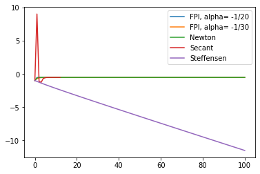

```python
F = lambda x: 10*x**2 - 4*x - 5
dF = lambda x: 20*x - 4
#1 - alpha*(20*x + 4)
#FPI:
fpi1 = FPI(F, -1, -1/20)
fpi2 = FPI(F, -1, -1/30)
#Newton:
newt = newton(F, dF, -1)
#secant:
sec = secant(F,-1)
#steffensen:
stef = steffensen(F,-1)
L = lambda X: list(range(len(X)))

for method, result in zip(["FPI, alpha=-1/20","FPI, alpha=-1/30","Newton's Method","Secant Method","Steffensen's Method"],[fpi1, fpi2, newt, sec, stef]):
    print(f"{method}: {result[-1]}")

plt.plot(L(fpi1),fpi1, label="FPI, alpha= -1/20")
plt.plot(L(fpi2),fpi2, label="FPI, alpha= -1/30")
plt.plot(L(newt),newt,label="Newton")
plt.plot(L(sec),sec, label="Secant")
plt.plot(L(stef),stef, label="Steffensen")
plt.legend()
plt.show
```

### b)

```
FPI, alpha=2.5: 1.0242696071414192
FPI, alpha=1: 1.03935015272538
Newton's Method: 1.0000060716137125
Secant Method: 1.0000035002296985
Steffensen's Method: 1.0003166415823173
```

```
<function matplotlib.pyplot.show(*args, **kw)>
```

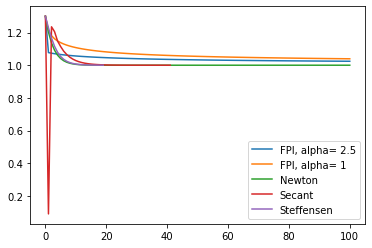

```python
F = lambda x: x**4 - x**3 - 3*x**2 + 5*x - 2
dF = lambda x: 4*x**3 - 3*x**2 -6*x + 5

#FPI:
fpi1 = FPI(F, 1.3, 2.5)
fpi2 = FPI(F, 1.3, 1)
#Newton:
newt = newton(F, dF, 1.3)
#secant:
sec = secant(F,1.3)
#steffensen:
stef = steffensen(F,1.3)
L = lambda X: list(range(len(X)))

for method, result in zip(["FPI, alpha=2.5","FPI, alpha=1","Newton's Method","Secant Method","Steffensen's Method"],[fpi1, fpi2, newt, sec, stef]):
    print(f"{method}: {result[-1]}")

plt.plot(L(fpi1),fpi1, label="FPI, alpha= 2.5")
plt.plot(L(fpi2),fpi2, label="FPI, alpha= 1")
plt.plot(L(newt),newt, label="Newton")
plt.plot(L(sec),sec, label="Secant")
plt.plot(L(stef),stef, label="Steffensen")
plt.legend()
plt.show
```

### c)

```
FPI, alpha=-1: 2.219107148913746
FPI, alpha=-3: 2.2191071489014393
Newton's Method: 2.219107148913746
Secant Method: 2.219107148913746
Steffensen's Method: 2.219107148913746
```

```
<function matplotlib.pyplot.show(*args, **kw)>
```

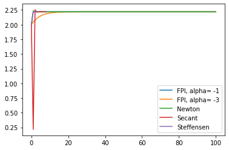

```python
F = lambda x: math.sin(x) - math.log(x)
dF = lambda x: math.cos(x) - 1/x

#FPI:
fpi1 = FPI(F, 2, -1)
fpi2 = FPI(F, 2, -0.2)
#Newton:
newt = newton(F, dF, 2)
#secant:
sec = secant(F,2)
#steffensen:
stef = steffensen(F,2)

for method, result in zip(["FPI, alpha=-1","FPI, alpha=-3","Newton's Method","Secant Method","Steffensen's Method"],[fpi1, fpi2, newt, sec, stef]):
    print(f"{method}: {result[-1]}")

plt.plot(L(fpi1),fpi1, label="FPI, alpha= -1")
plt.plot(L(fpi2),fpi2, label="FPI, alpha= -3")
plt.plot(L(newt),newt, label="Newton")
plt.plot(L(sec),sec, label="Secant")
plt.plot(L(stef),stef, label="Steffensen")
plt.legend()
plt.show
```

# Problem 10

### a)

```python
F = lambda x: 10*x**2 - 4*x + 5
dF = lambda x: 20*x - 4
tol = 10**-5
a1, a2, a3 = 1/100, 1/20, 2

def FPI2(f, x0, alpha, tol=tol):
  g = lambda x: x - alpha*f(x)
  x = x0
  count = 0
  while abs(f(x)) >= tol and count < 100:
    x = g(x)
    count += 1
  print(f"Alpha = {alpha}\nx* = {x}\nCompleted in {count} iterations.\n")


FPI2(dF, 0, a1)
FPI2(dF, 0, a2)
FPI2(dF, 0, a3)
```

```
Alpha = 0.01
x* = 0.1999995210951435
Completed in 58 iterations.

Alpha = 0.05
x* = 0.2
Completed in 1 iterations.

Alpha = 2
x* = -255558716510693824674537449010434911861914569149854421106803114134089547153738625028717782550797070641885149999885800538671581040229223258427250623004869423200
Completed in 100 iterations.
```

### b)

```python
d2F = lambda x: 20

def newton2(f, df, x0, tol=tol):
  x = x0
  count = 0
  while abs(f(x)) >= tol and count < 100:
    x = x - f(x)/df(x)
    count += 1
  return (x,count)

x, count = newton2(dF,d2F,0)
print(f"x* = {x}\nCompleted in {count} iterations.")
```

```
x* = 0.2
Completed in 1 iterations.
```